# 1. Import drug screen data

#### 3.4.1.32 E76908mtx17

🔍 Zoom In for Details

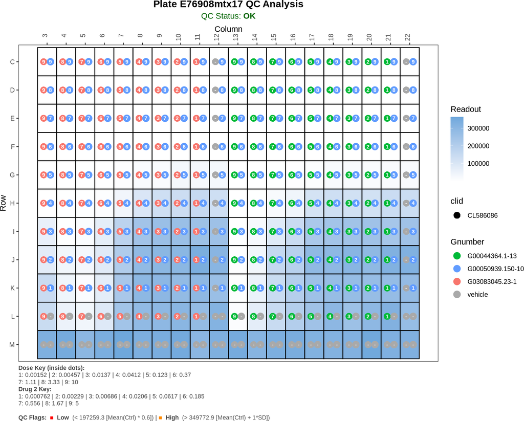

#### 3.4.1.33 E74908mtx17

🔍 Zoom In for Details

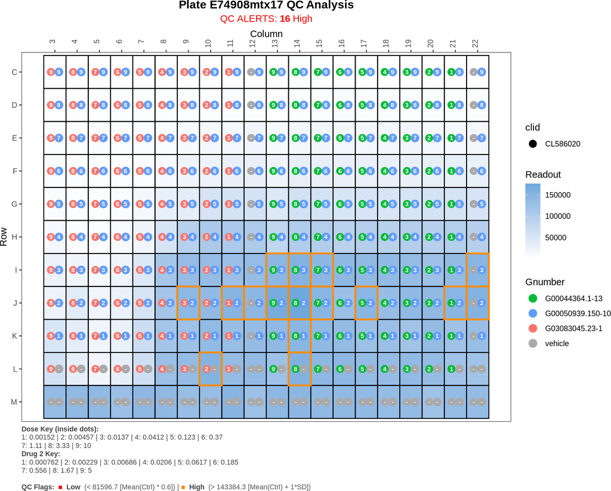

#### 3.4.1.34 E90915mtx17

🔍 Zoom In for Details

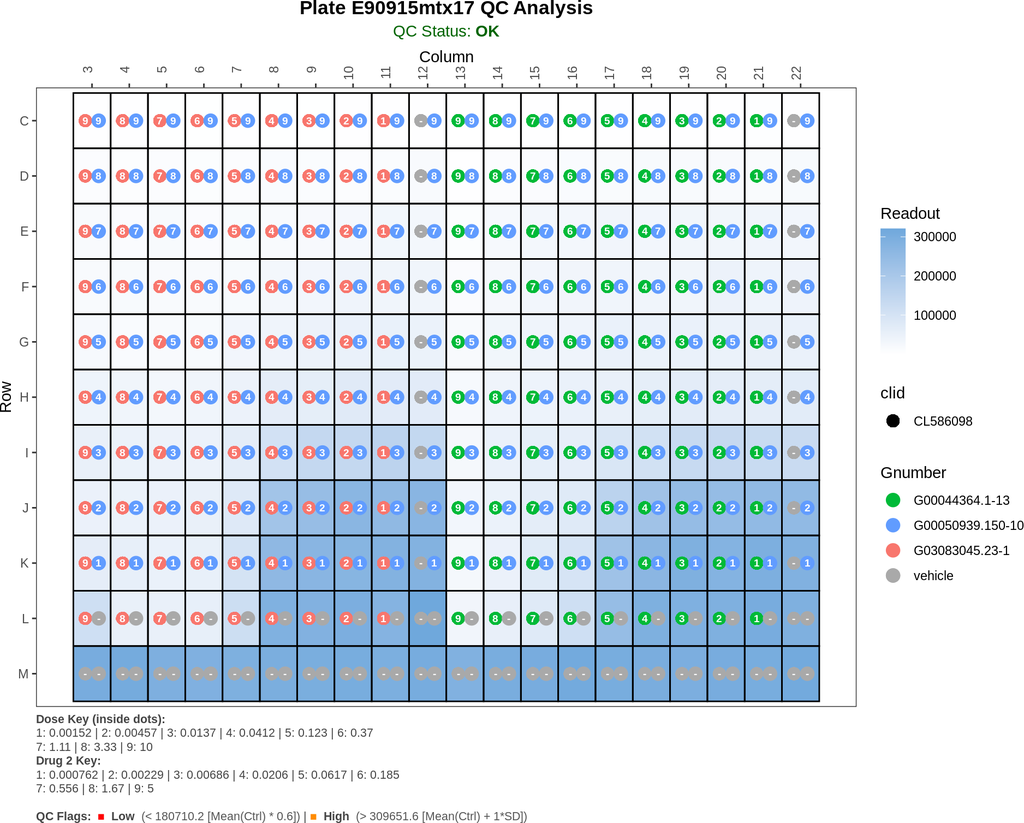

#### 3.4.1.35 E86903mtx17

🔍 Zoom In for Details

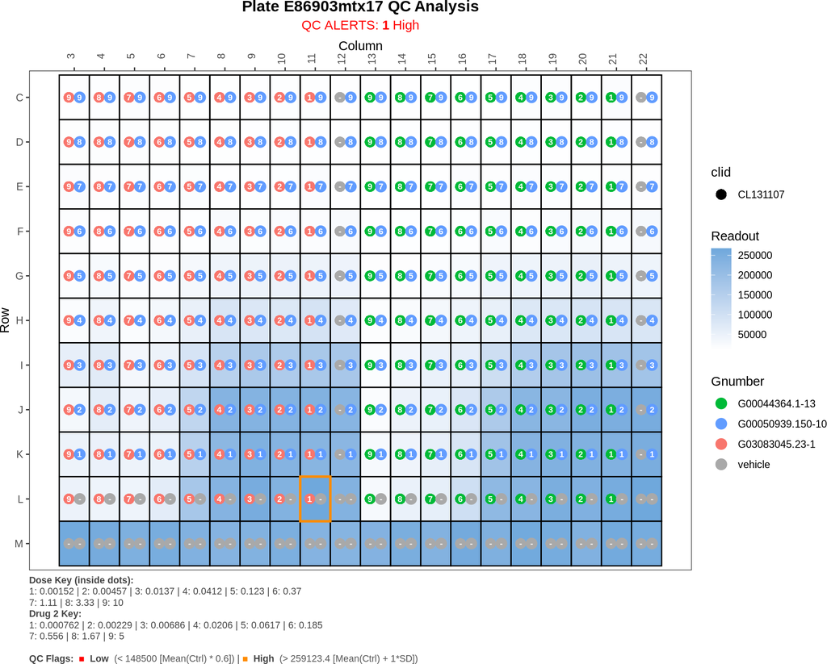

#### 3.4.1.36 H03915mtx17

🔍 Zoom In for Details

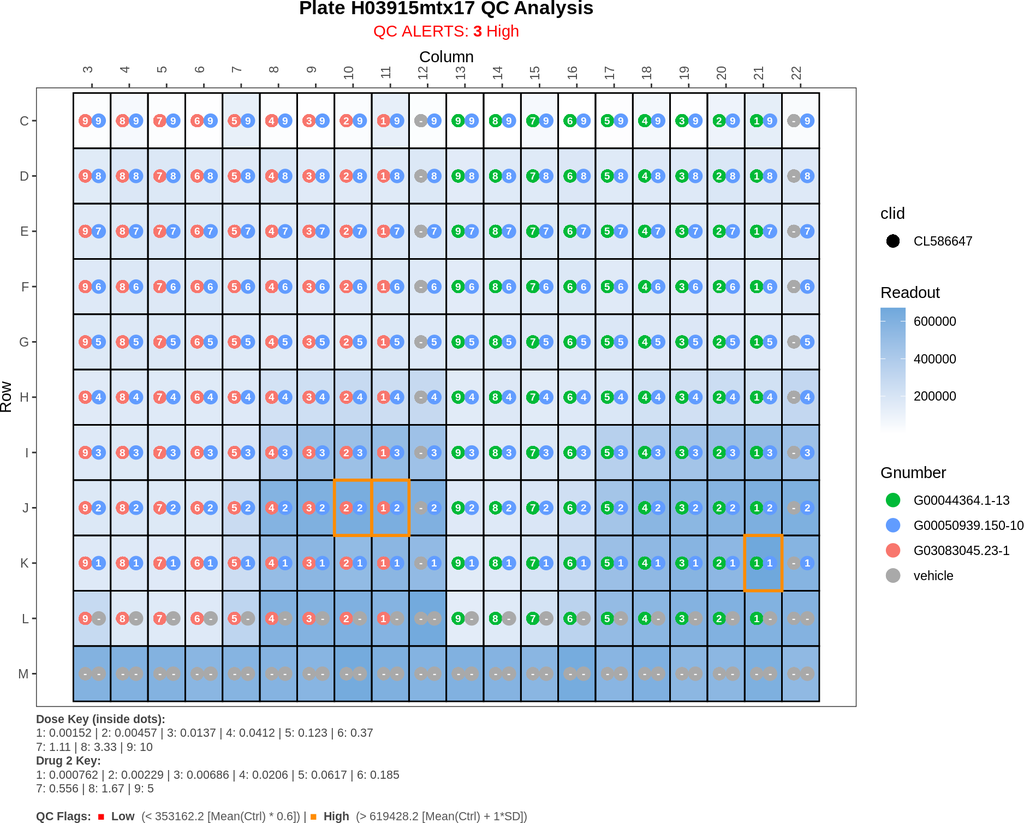

#### 3.4.1.37 E75908mtx17

🔍 Zoom In for Details

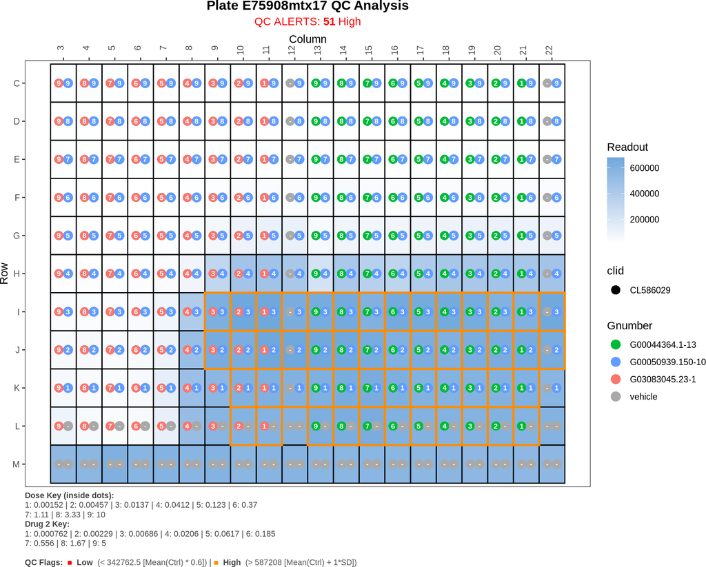

#### 3.4.1.38 K16915mtx17

🔍 Zoom In for Details

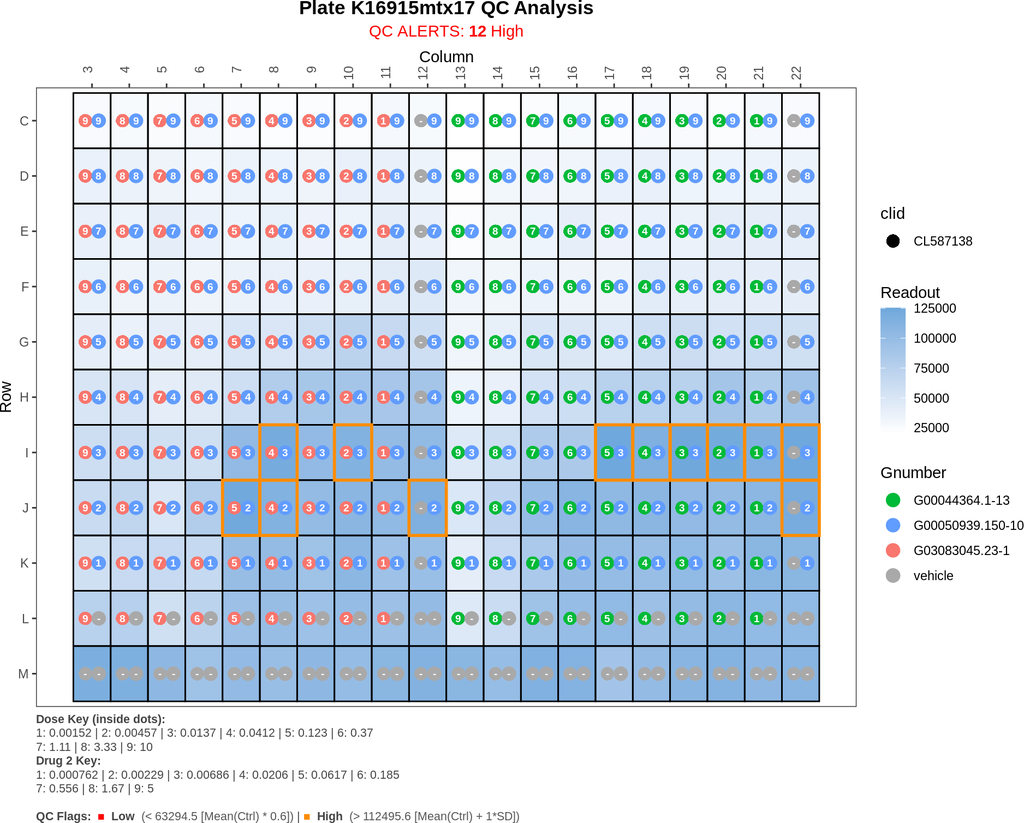

#### 3.4.1.39 E73903mtx17

🔍 Zoom In for Details

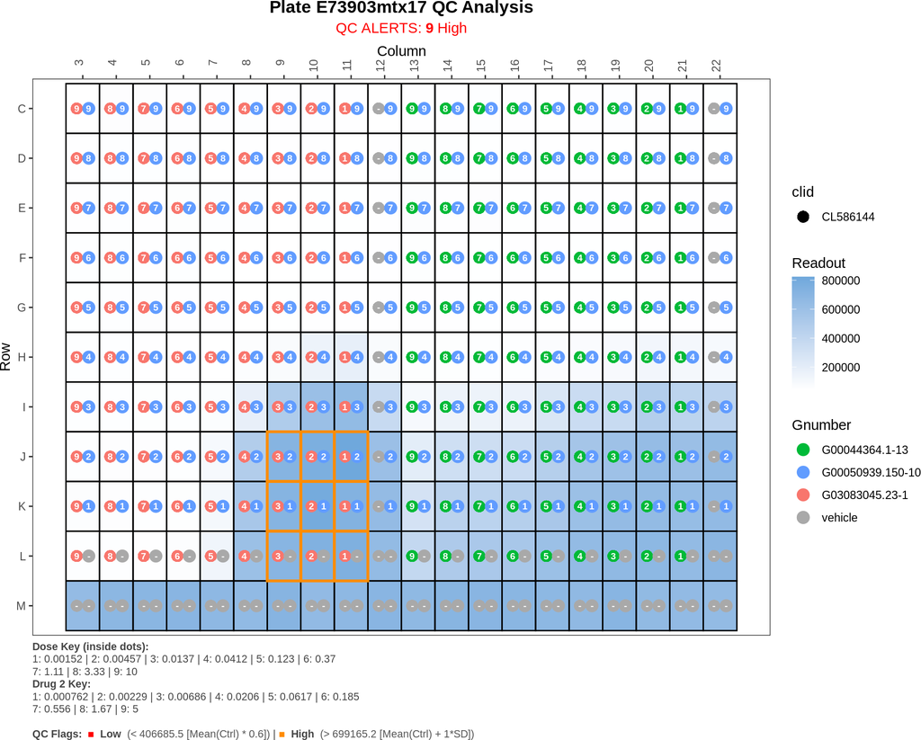

#### 3.4.1.40 E92915mtx17

🔍 Zoom In for Details

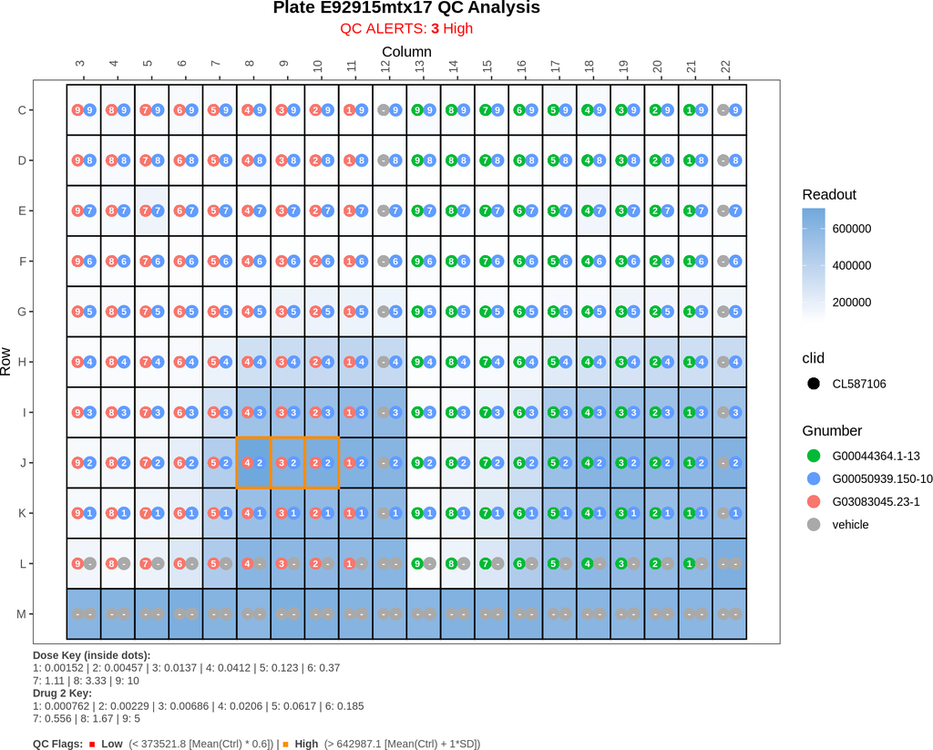

#### 3.4.1.41 H16908mtx17

🔍 Zoom In for Details

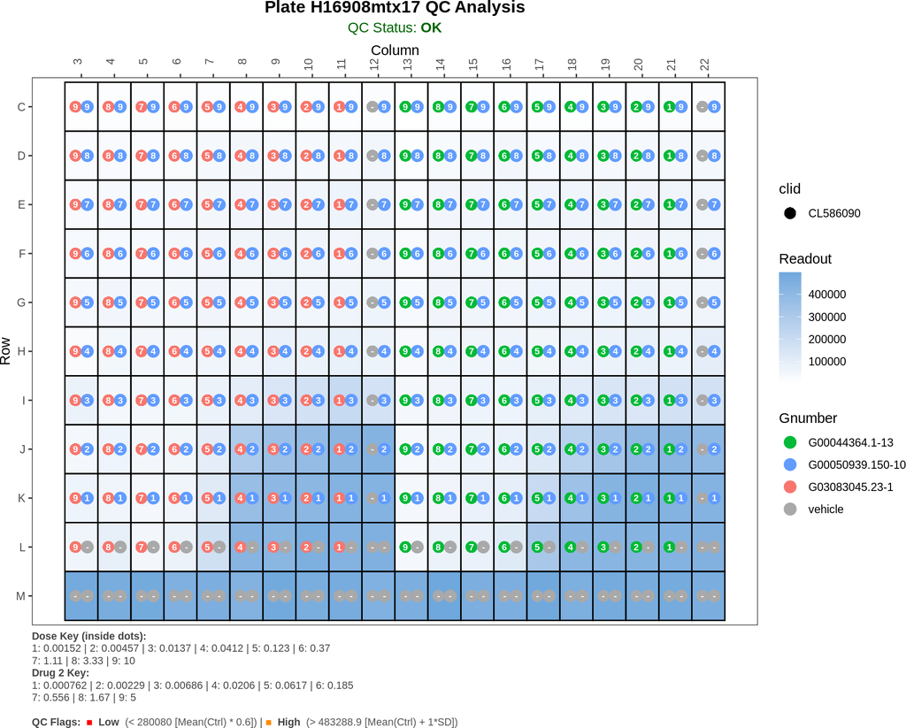

#### 3.4.1.42 E91908mtx17

🔍 Zoom In for Details

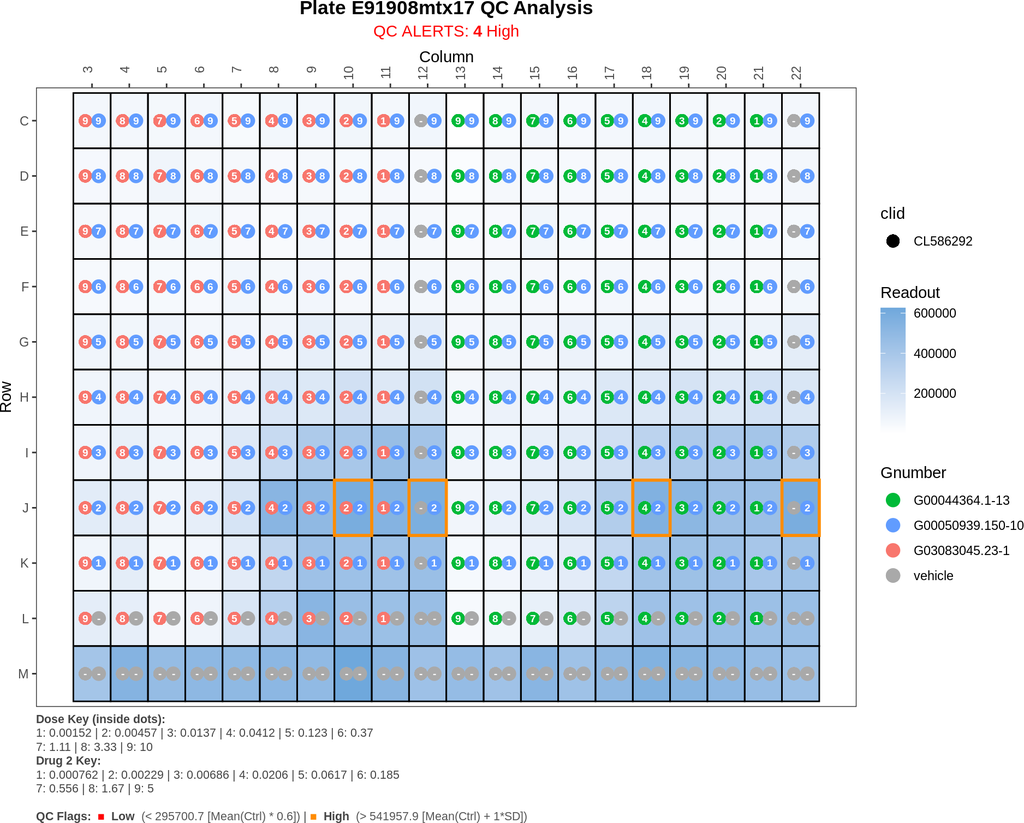

#### 3.4.1.43 H24908mtx17

🔍 Zoom In for Details

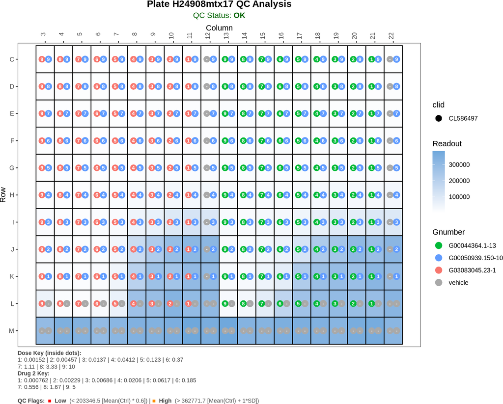

Before executing the pipeline, there exists a provision for manual alterations within the raw data. This allows for the manual modification of certain annotations and the correction of data as needed.

```r
# preview the annotation used in the preprocessing
drug_annotation_path <- file.path(wd, "data_annotation", "drug_annotation.csv")
drug_annotation <- if (file.exists(drug_annotation_path)) {
  fread(drug_annotation_path)
} else {
  get_drug_annotation_from_dt(data_imported)
}
data_imported <- annotate_dt_with_drug(data_imported, drug_annotation)
fwrite(drug_annotation, drug_annotation_path)
generate_datatable(drug_annotation)
```

|  | Gnumber | DrugName | drug_moa |
| --- | --- | --- | --- |
| 1 | G03083045.23-1 | Belvarafenib | BRAF\|RAF1\|ARAF |
| 2 | G00044364.1-13 | Vemurafenib | BRAF |
| 3 | G00050939.150-10 | Cobimetinib | MAP2K1\|MAP2K2 |

```r
cell_line_annotation_path <- file.path(wd, "data_annotation", "cell_line_annotation.csv")
cell_line_annotation <- if (file.exists(cell_line_annotation_path)) {
  fread(cell_line_annotation_path)
} else {
  get_cellline_annotation_from_dt(data_imported)
}
data_imported <- annotate_dt_with_cell_line(data_imported, cell_line_annotation)
fwrite(cell_line_annotation, cell_line_annotation_path)
generate_datatable(cell_line_annotation)
```

|  | clid | CellLineName | Tissue | parental_identifier | subtype | ReferenceDivisionTime |
| --- | --- | --- | --- | --- | --- | --- |
| 1 | CL585679 | 501A | Skin | 501A | Melanoma | 27 |
| 2 | CL131311 | 624 mel | Skin | 501A | Melanoma | 26 |
| 3 | CL131257 | 928 mel | Skin | 928 mel | Melanoma | 27 |
| 4 | CL587462 | A-253 | Skin | A-253 | Carcinoma | 47 |
| 5 | CL584727 | A-375 | Skin | A-375 | Melanoma | 25 |
| 6 | CL583906 | A-431 | Skin | A-431 | Carcinoma Squamous Cell | 30 |
| 7 | CL586143 | A2058 | Skin | A2058 | Melanoma | 18 |
| 8 | CL587686 | A388 | Skin | A388 | Carcinoma Metastatic | 45 |
| 9 | CL586084 | COLO 800 | Skin | COLO 800 | Melanoma | 45 |
| 10 | CL131105 | COLO 829 | Skin | COLO 829 | Melanoma | 56 |

[output cut: 33 more lines]

```r
qs_save(data_imported, file.path(wd, "gDR_data", "gDR_input.qs2"))
```

# 4 Imported Data Summary

The table below summarizes the final, annotated dataset. This serves as a final check for data integrity. Key areas for review are:

- **Unique Values (`n_distinct`):** Confirms that the number of unique drugs, cell lines, and other identifiers matches the experimental design.
- **Missing Data (`% Miss`):** Look at the percentage of missing data in important columns like `ReadoutValue`.
- **Data Distribution:** Check the small histograms to see if the range and spread of your numeric data look reasonable.

```r
print(dfSummary(data_imported,
                varnumbers = FALSE,
                valid.col = FALSE,
                graph.magnif = 0.8,
                max.distinct.values = 50,
                max.string.width = 50,
                display.labels = FALSE),
      method = "render")
```

Data Frame Summary

data_imported

**Dimensions**: 9460 x 21  
**Duplicates**: 0

| **Variable** | **Stats / Values** | **Freqs (% of Valid)** | **Graph** | **Missing** |
| --- | --- | --- | --- | --- |
| clid [character] | 1. CL131105 2. CL131107 3. CL131109 4. CL131111 5. CL131257 6. CL131311 7. CL131317 8. CL131336 9. CL131382 10. CL583906 11. CL584727 12. CL585679 13. CL586020 14. CL586028 15. CL586029 16. CL586080 1… | 220 ( 2.3% ) 220 ( 2.3% ) 220 ( 2.3% ) 220 ( 2.3% ) 220 ( 2.3% ) 220 ( 2.3% ) 220 ( 2.3% ) 220 ( 2.3% ) 220 ( 2.3% ) 220 ( 2.3% ) 220 ( 2.3% ) 220 ( 2.3% ) 220 ( 2.3% ) 220 ( 2.3% ) 220 ( 2.3% ) 220 (… |  | 0 (0.0%) |
| CellLineName [character] | 1. 501A 2. 624 mel 3. 928 mel 4. A-253 5. A-375 6. A-431 7. A2058 8. A388 9. COLO 800 10. COLO 829 11. COLO 849 12. COLO 853 13. COLO 857 14. COLO 858 15. G-361 16. HCC1498 17. HMY-1 18. Hs 294T 19. H… | 220 ( 2.3% ) 220 ( 2.3% ) 220 ( 2.3% ) 220 ( 2.3% ) 220 ( 2.3% ) 220 ( 2.3% ) 220 ( 2.3% ) 220 ( 2.3% ) 220 ( 2.3% ) 220 ( 2.3% ) 220 ( 2.3% ) 220 ( 2.3% ) 220 ( 2.3% ) 220 ( 2.3% ) 220 ( 2.3% ) 220 (… |  | 0 (0.0%) |
| Tissue [character] | 1. Skin | 9460 ( 100.0% ) |  | 0 (0.0%) |
| parental_identifier [character] | 1. 501A 2. 928 mel 3. A-253 4. A-375 5. A-431 6. A101D 7. A2058 8. A388 9. COLO 800 10. COLO 829 11. COLO 849 12. COLO 853 13. COLO 857 14. COLO 858 15. G-361 16. HCC1498 17. HMY-1 18. Hs 695T 19. Hs … | 440 ( 4.7% ) 220 ( 2.3% ) 220 ( 2.3% ) 220 ( 2.3% ) 220 ( 2.3% ) 220 ( 2.3% ) 220 ( 2.3% ) 220 ( 2.3% ) 220 ( 2.3% ) 220 ( 2.3% ) 220 ( 2.3% ) 220 ( 2.3% ) 220 ( 2.3% ) 220 ( 2.3% ) 220 ( 2.3% ) 220 (… |  | 0 (0.0%) |
| subtype [character] | 1. Carcinoma 2. Carcinoma Metastatic 3. Carcinoma Squamous Cell 4. Melanoma 5. Melanoma Metastatic | 220 ( 2.3% ) 220 ( 2.3% ) 660 ( 7.0% ) 7700 ( 81.4% ) 660 ( 7.0% ) |  | 0 (0.0%) |
| ReferenceDivisionTime [numeric] | Mean (sd) : 41.4 (15.2) min ≤ med ≤ max: 18 ≤ 39 ≤ 82 IQR (CV) : 22.2 (0.4) | 18 : 440 ( 5.0% ) 20 : 220 ( 2.5% ) 25 : 220 ( 2.5% ) 26 : 440 ( 5.0% ) 27 : 660 ( 7.5% ) 29 : 440 ( 5.0% ) 30 : 440 ( 5.0% ) 31 : 660 ( 7.5% ) 35 : 440 ( 5.0% ) 36 : 220 ( 2.5% ) 39 : 440 ( 5.0% ) 45… |  | 660 (7.0%) |
| Gnumber [character] | 1. G00044364.1-13 2. G03083045.23-1 3. vehicle | 3870 ( 40.9% ) 3870 ( 40.9% ) 1720 ( 18.2% ) |  | 0 (0.0%) |
| DrugName [character] | 1. Belvarafenib 2. vehicle 3. Vemurafenib | 3870 ( 40.9% ) 1720 ( 18.2% ) 3870 ( 40.9% ) |  | 0 (0.0%) |
| drug_moa [character] | 1. BRAF 2. BRAF\|RAF1\|ARAF 3. vehicle | 3870 ( 40.9% ) 3870 ( 40.9% ) 1720 ( 18.2% ) |  | 0 (0.0%) |
| Gnumber_2 [character] | 1. G00050939.150-10 2. vehicle | 7740 ( 81.8% ) 1720 ( 18.2% ) |  | 0 (0.0%) |
| DrugName_2 [character] | 1. Cobimetinib 2. vehicle | 7740 ( 81.8% ) 1720 ( 18.2% ) |  | 0 (0.0%) |
| drug_moa_2 [character] | 1. MAP2K1\|MAP2K2 2. vehicle | 7740 ( 81.8% ) 1720 ( 18.2% ) |  | 0 (0.0%) |
| Duration [numeric] | 1 distinct value | 120 : 9460 ( 100.0% ) |  | 0 (0.0%) |
| Concentration [numeric] | Mean (sd) : 1.4 (2.9) min ≤ med ≤ max: 0 ≤ 0 ≤ 10 IQR (CV) : 1.1 (2.1) | 10 distinct values |  | 0 (0.0%) |
| Concentration_2 [numeric] | Mean (sd) : 0.7 (1.4) min ≤ med ≤ max: 0 ≤ 0 ≤ 5 IQR (CV) : 0.6 (2.1) | 10 distinct values |  | 0 (0.0%) |
| Barcode [character] | 1. E63903mtx17 2. E68903mtx17 3. E73903mtx17 4. E74908mtx17 5. E75908mtx17 6. E76908mtx17 7. E77903mtx17 8. E78903mtx17 9. E79903mtx17 10. E80903mtx17 11. E81903mtx17 12. E82903mtx17 13. E83903mtx17 1… | 220 ( 2.3% ) 220 ( 2.3% ) 220 ( 2.3% ) 220 ( 2.3% ) 220 ( 2.3% ) 220 ( 2.3% ) 220 ( 2.3% ) 220 ( 2.3% ) 220 ( 2.3% ) 220 ( 2.3% ) 220 ( 2.3% ) 220 ( 2.3% ) 220 ( 2.3% ) 220 ( 2.3% ) 220 ( 2.3% ) 220 (… |  | 0 (0.0%) |
| Template [character] | 1. P41.Belva.mtx17.template.xlsx | 9460 ( 100.0% ) |  | 0 (0.0%) |
| ReadoutValue [numeric] | Mean (sd) : 191933.1 (182654.2) min ≤ med ≤ max: 160 ≤ 120520 ≤ 856120 IQR (CV) : 268720 (1) | 6145 distinct values |  | 0 (0.0%) |
| BackgroundValue [numeric] | 1 distinct value | 0 : 9460 ( 100.0% ) |  | 0 (0.0%) |
| WellRow [character] | 1. C 2. D 3. E 4. F 5. G 6. H 7. I 8. J 9. K 10. L 11. M | 860 ( 9.1% ) 860 ( 9.1% ) 860 ( 9.1% ) 860 ( 9.1% ) 860 ( 9.1% ) 860 ( 9.1% ) 860 ( 9.1% ) 860 ( 9.1% ) 860 ( 9.1% ) 860 ( 9.1% ) 860 ( 9.1% ) |  | 0 (0.0%) |
| WellColumn [character] | 1. 10 2. 11 3. 12 4. 13 5. 14 6. 15 7. 16 8. 17 9. 18 10. 19 11. 20 12. 21 13. 22 14. 3 15. 4 16. 5 17. 6 18. 7 19. 8 20. 9 | 473 ( 5.0% ) 473 ( 5.0% ) 473 ( 5.0% ) 473 ( 5.0% ) 473 ( 5.0% ) 473 ( 5.0% ) 473 ( 5.0% ) 473 ( 5.0% ) 473 ( 5.0% ) 473 ( 5.0% ) 473 ( 5.0% ) 473 ( 5.0% ) 473 ( 5.0% ) 473 ( 5.0% ) 473 ( 5.0% ) 473 (… |  | 0 (0.0%) |

Generated by summarytools 1.1.4 ([R](https://www.r-project.org/) version 4.5.0)  
2026-06-01

# 5 Conclusion

The data import and quality control step is complete. The final dataset has been saved to `gDR_data/gDR_input.qs2`.

### We Value Your Feedback!

Thank you for using gDR! We are always looking to improve, and your feedback is incredibly valuable to us.

[Share feedback or request features on GitHub](https://github.com/gdrplatform/gDRworkshops/issues)

# 6 gDR session info

```r
gdr_sdt <- get_gDR_session_info()
generate_datatable(gdr_sdt)
```

|  | Package | Version |
| --- | --- | --- |
| 1 | gDRcore | 1.9.7 |
| 2 | gDRimport | 1.9.9 |
| 3 | gDRinternal | 1.0.263 |
| 4 | gDRplots | 0.0.107 |
| 5 | gDRutils | 1.9.8 |
| 6 | gDR | 1.7.2 |
| 7 | gDRcomponents | 1.4.123 |
| 8 | gDRin | 0.2.92 |
| 9 | gDRinternalData | 0.0.13 |
| 10 | gDRinternalShiny | 0.0.21 |

[output cut: 6 more lines]